# R_mini_project

R Gae MI

2021 5 17

### 데이터 수집에 활용한 사이트 목록

- e-나라지표 https://www.index.go.kr/
- 한국 부동산원 http://www.reb.or.kr/kab/home/main/main.jsp
- 국가 통계 포털 https://kosis.kr/index/index.do

### 라이브러리 로드

```r
library(readxl)
```

```r
library(corrplot)
library(car)
library(MASS)
library(lm.beta)
```

### 데이터 인풋

```r
data0 <-read_excel("C:/ken/r_pr_data.xlsx")
```

### 변수 설명

#### 데이터 기간(2017.10 ~ 2021.02, 총 41개월)

- stock : 개인 주식 투자 금액 지수 (2017.11기준)
- house : 전국 아파트 실거래가 지수 (2017.11기준)
- y_job : 청년 실업률
- job : 전체 실업률
- moneyrate : 기준 금리
- coin : 가상화폐 투자 공포 탐욕 지수
- foreigner : 주식시장 내 외국인 보유비율
- customerprice : 소비자 물가 지수 (2015년 기준)

### 데이터 구조 확인

```r
str(data0)
```

```
## tibble[,8] [41 x 8] (S3: tbl_df/tbl/data.frame)
##  $ stock        : num [1:41] 52 100 82.9 129.7 80.6 ...
##  $ house        : num [1:41] 100.3 100 99.7 99.9 100.4 ...
##  $ y_job        : num [1:41] 8.6 9.2 9.2 8.7 9.8 11.6 10.7 10.5 9 9.3 ...
##  $ job          : num [1:41] 3.2 3.1 3.3 3.7 4.6 4.5 4.1 4 3.7 3.7 ...
##  $ moneyrate    : num [1:41] 1.25 1.5 1.5 1.5 1.5 1.5 1.5 1.5 1.5 1.5 ...
##  $ coin         : num [1:41] 61.1 76.5 86.7 49.9 32.1 ...
##  $ foreigner    : num [1:41] 34.6 33.8 33.6 33 32.9 32.7 32.8 32.7 32.7 33 ...
##  $ customerprice: num [1:41] 103 103 103 103 104 ...
```

### 기초통계량 확인

```r
summary(data0)
```

```
##      stock            house            y_job             job
##  Min.   : 50.94   Min.   : 99.48   Min.   : 7.000   Min.   :3.000
##  1st Qu.: 61.77   1st Qu.:100.20   1st Qu.: 8.300   1st Qu.:3.400
##  Median : 80.62   Median :101.40   Median : 9.200   Median :4.000
##  Mean   :117.22   Mean   :105.02   Mean   : 9.129   Mean   :3.876
##  3rd Qu.:154.70   3rd Qu.:106.32   3rd Qu.: 9.900   3rd Qu.:4.200
##  Max.   :324.88   Max.   :127.69   Max.   :11.600   Max.   :5.700
##    moneyrate          coin         foreigner    customerprice
##  Min.   :0.500   Min.   :28.41   Min.   :30.0   Min.   :102.6
##  1st Qu.:0.750   1st Qu.:42.96   1st Qu.:31.6   1st Qu.:104.3
##  Median :1.500   Median :48.75   Median :32.7   Median :104.9
##  Mean   :1.232   Mean   :52.82   Mean   :32.4   Mean   :104.9
##  3rd Qu.:1.500   3rd Qu.:62.49   3rd Qu.:33.1   3rd Qu.:105.5
##  Max.   :1.750   Max.   :86.69   Max.   :34.6   Max.   :107.0
```

### house만을 이용한 단순선형 회귀분석

**편의를 위해 회귀식들은 소수점 셋째자리에서 반올림 처리**  
추정된 회귀식

#### $\hat{stock}=-837.82+9.09house$

house변수 하나만을 가지고 만든 회귀식의 경우, 수정된 $R^2$값이 0.787이고, $p-value$가 매우 작아 유의한 검정으로 볼 수 있다.

```r
result0 <- lm(stock~house, data=data0)
summary(result0)
```

```
##
## Call:
## lm(formula = stock ~ house, data = data0)
##
## Residuals:
##     Min      1Q  Median      3Q     Max
## -98.319 -23.004  -4.002  22.596  67.076
##
## Coefficients:
##              Estimate Std. Error t value Pr(>|t|)
## (Intercept) -837.8239    78.4790  -10.68 3.89e-13 ***
## house          9.0938     0.7455   12.20 6.91e-15 ***
## ---
## Signif. codes:  0 '***' 0.001 '**' 0.01 '*' 0.05 '.' 0.1 ' ' 1
##
## Residual standard error: 34.95 on 39 degrees of freedom
## Multiple R-squared:  0.7923, Adjusted R-squared:  0.787
## F-statistic: 148.8 on 1 and 39 DF,  p-value: 6.911e-15
```

### 1차 다중회귀분석 변수 선택

설명력을 더 높이기 위해서 house이외에 y_job, job, moneyrate 변수를 추가로 사용했다.

```r
data1 <- data0[c('stock','house','y_job','job','moneyrate')]
head(data1)
```

```
## # A tibble: 6 x 5
##   stock house y_job   job moneyrate
##   <dbl> <dbl> <dbl> <dbl>     <dbl>
## 1  52.0 100.    8.6   3.2      1.25
## 2 100   100     9.2   3.1      1.5
## 3  82.9  99.7   9.2   3.3      1.5
## 4 130.   99.9   8.7   3.7      1.5
## 5  80.6 100.    9.8   4.6      1.5
## 6  91.5 100.   11.6   4.5      1.5
```

### 변수간 상관관계 파악

y_job과 job중에서 상관계수가 더 낮은 y_job을 제거하기로 결정했다.  
또한 stock과 나머지 변수들간의 상관계수가 0.3이상이며, 어느정도 선형성을 가지고 있는 것을 확인할 수 있다.

```r
cor(data1)
```

```
##                 stock       house       y_job        job  moneyrate
## stock      1.00000000  0.89013862  0.03593275  0.3376034 -0.8853730
## house      0.89013862  1.00000000 -0.09197738  0.3454285 -0.8535554
## y_job      0.03593275 -0.09197738  1.00000000  0.6592215  0.1054085
## job        0.33760341  0.34542847  0.65922152  1.0000000 -0.1827480
## moneyrate -0.88537296 -0.85355544  0.10540847 -0.1827480  1.0000000
```

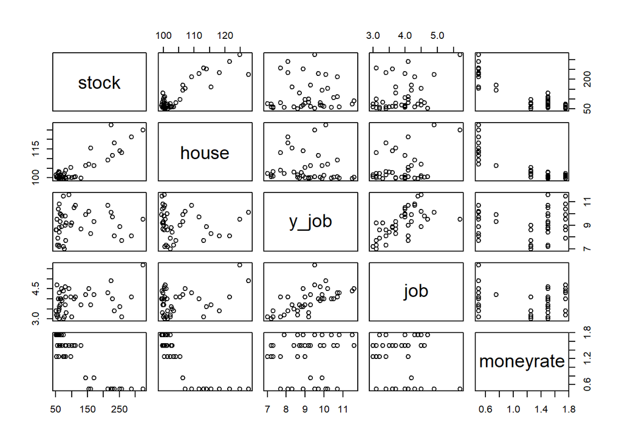

```r
pairs(data1)
```

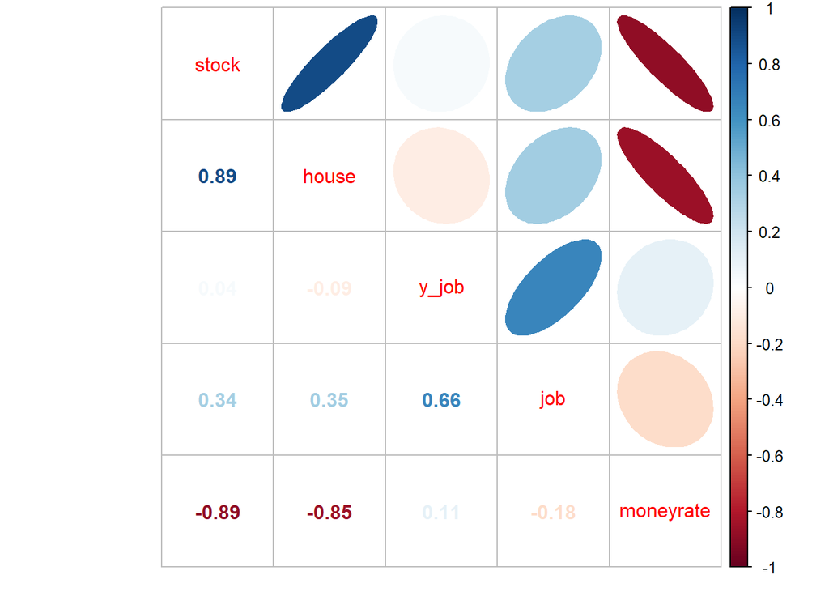

```r
corrplot::corrplot.mixed(cor(data1),upper='ellipse')
```

### 다중 회귀분석

추정된 회귀식

#### $\hat{stock} = -290.32+4.36house+12.51job-80.13moneyrate$

이 회귀식의 설명력인 수정된 $R^2$값은0.847이며,이는 house변수 하나만을 사용했을 때 보다 증가한 값이다. $p-value$가 0에 가까워 이 회귀 모델이 유의함을 알 수 있다.  
하지만 각 독립변수의 $p-value$를 살펴보았을 때, job이 0.15로 0.05보다 크기 때문에 회귀계수의 유의성이 의심된다.

```r
result1<-lm(stock~house+job+moneyrate,data=data1)
summary(result1)
```

```
##
## Call:
## lm(formula = stock ~ house + job + moneyrate, data = data1)
##
## Residuals:
##     Min      1Q  Median      3Q     Max
## -62.421 -16.970   2.046  15.161  58.297
##
## Coefficients:
##             Estimate Std. Error t value Pr(>|t|)
## (Intercept) -290.316    149.530  -1.942  0.05984 .
## house          4.359      1.305   3.340  0.00192 **
## job           12.509      8.618   1.451  0.15508
## moneyrate    -80.130     19.416  -4.127  0.00020 ***
## ---
## Signif. codes:  0 '***' 0.001 '**' 0.01 '*' 0.05 '.' 0.1 ' ' 1
##
## Residual standard error: 29.62 on 37 degrees of freedom
## Multiple R-squared:  0.8585, Adjusted R-squared:  0.847
## F-statistic: 74.83 on 3 and 37 DF,  p-value: 8.949e-16
```

### 다중공선성 확인

10을 넘는 변수가 따로 보이지 않으므로 양호하다고 판단한다.

```r
vif(result1)
```

```
##     house       job moneyrate
##  4.267768  1.198482  3.888395
```

### 회귀분석의 가정

- 선형성 (변수 간 상관관계에서 확인)
- 독립성
- 정규성
- 등분산성

### 독립성 확인

$H_0$ : 잔차들이 서로 독립적이다.  
$H_1$ : 잔차들이 서로 독립적이지 않다.  
D-W Statistic 값이 1.46이고, p-value가 0.05보다 작아 잔차들이 서로 독립적이지 않다. 그렇기 때문에 나머지 부분을 설명할 새로운 변수의 추가가 필요하다.

```r
durbinWatsonTest(result1)
```

```
##  lag Autocorrelation D-W Statistic p-value
##    1       0.1899558       1.46302    0.03
##  Alternative hypothesis: rho != 0
```

### 새로운 변수 투입

가상화폐 지수, 주식시장에서의 외국인 지분율, 소비자 물가지수

```r
data2 <- data0[c('stock','house','job','moneyrate','coin','foreigner','customerprice')]
head(data2)
```

```
## # A tibble: 6 x 7
##   stock house   job moneyrate  coin foreigner customerprice
##   <dbl> <dbl> <dbl>     <dbl> <dbl>     <dbl>         <dbl>
## 1  52.0 100.    3.2      1.25  61.1      34.6          103.
## 2 100   100     3.1      1.5   76.5      33.8          103.
## 3  82.9  99.7   3.3      1.5   86.7      33.6          103.
## 4 130.   99.9   3.7      1.5   49.9      33            103.
## 5  80.6 100.    4.6      1.5   32.1      32.9          104.
## 6  91.5 100.    4.5      1.5   28.4      32.7          104.
```

### 변수간 상관관계 파악

특이점 있는 변수는 없는 것으로 판단됨.  
stock과 다른 변수들의 상관관계를 보았을 때, 상관계수가 0.3이상이며 적당한 선형성이 존재하고 있음을 알 수 있다.

```r
cor(data2)
```

```
##                    stock      house        job  moneyrate        coin
## stock          1.0000000  0.8901386  0.3376034 -0.8853730  0.39663895
## house          0.8901386  1.0000000  0.3454285 -0.8535554  0.40082227
## job            0.3376034  0.3454285  1.0000000 -0.1827480  0.12074959
## moneyrate     -0.8853730 -0.8535554 -0.1827480  1.0000000 -0.29976986
## coin           0.3966389  0.4008223  0.1207496 -0.2997699  1.00000000
## foreigner     -0.7335571 -0.6619969 -0.2713717  0.6808660 -0.11384521
## customerprice  0.4941167  0.6978144  0.2920704 -0.5400510  0.08401998
##                foreigner customerprice
## stock         -0.7335571    0.49411665
## house         -0.6619969    0.69781444
## job           -0.2713717    0.29207039
## moneyrate      0.6808660   -0.54005104
## coin          -0.1138452    0.08401998
## foreigner      1.0000000   -0.46463703
## customerprice -0.4646370    1.00000000
```

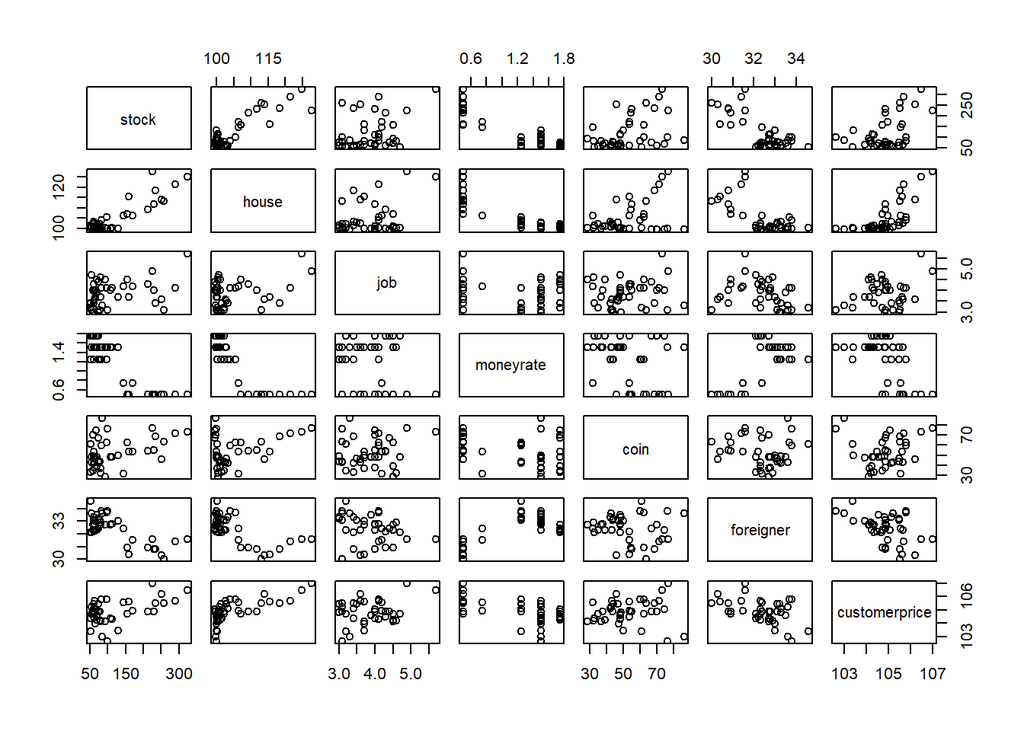

```r
pairs(data2)
```

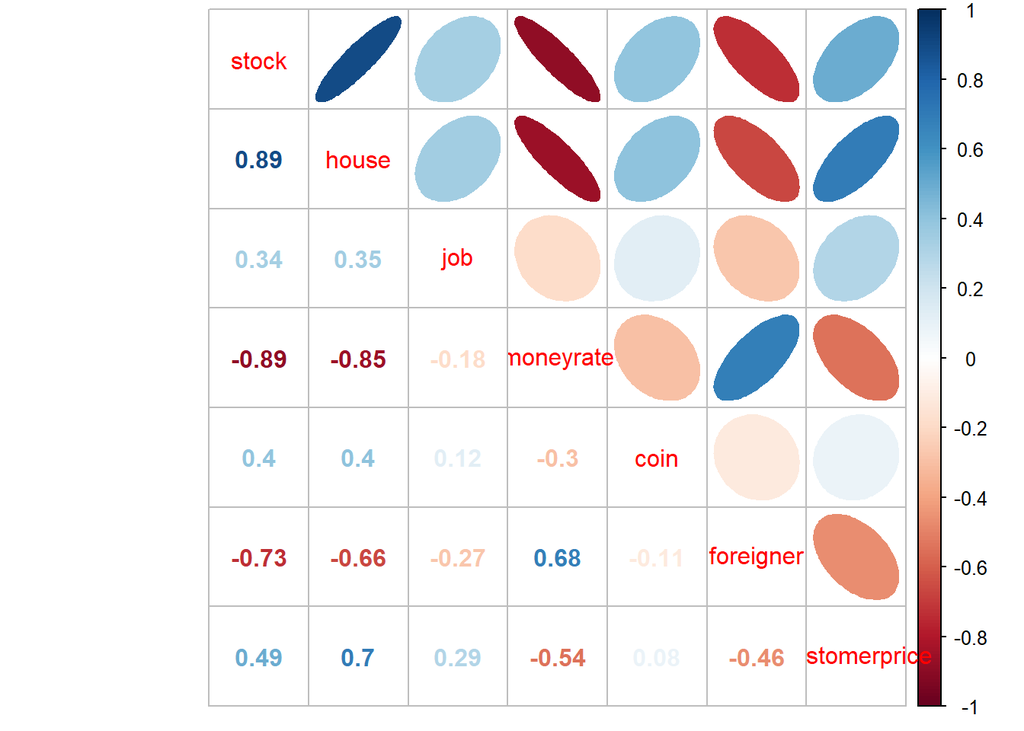

```r
corrplot::corrplot.mixed(cor(data2),upper='ellipse')
```

### 회귀분석

#### $\hat{stock}=1733.93+5.28house+11.07job-61.84moneyrate+0.3coin-13.1foreigner-16.49customerprice$

이 회귀식의 수정된 $R^2$는 0.8794이며, 마찬가지로 result1보다 증가한 수치임을 알 수 있다.  
$p-value$값은 매우 낮아 이 회귀 모형은 통계적으로 유의하다고 할 수 있다.  
각각의 변수들을 살펴보면, 다른 변수들의 $p-value$ 0.05이하로 유의하다고 볼 수 있으나 coin과 job은 0.05이상이므로 회귀계수가 0은 아닌지 의심해 볼 필요가 있다고 판단된다.

```r
result2 <- lm(stock~house+job+moneyrate+coin+foreigner+customerprice,data=data2)
summary(result2)
```

```
##
## Call:
## lm(formula = stock ~ house + job + moneyrate + coin + foreigner +
##     customerprice, data = data2)
##
## Residuals:
##     Min      1Q  Median      3Q     Max
## -70.133  -8.582   2.712   8.694  47.375
##
## Coefficients:
##                Estimate Std. Error t value Pr(>|t|)
## (Intercept)   1733.9250   686.2334   2.527  0.01633 *
## house            5.2799     1.4874   3.550  0.00115 **
## job             11.0681     7.7314   1.432  0.16139
## moneyrate      -61.8394    18.4350  -3.354  0.00196 **
## coin             0.3026     0.3402   0.889  0.38001
## foreigner      -13.0977     5.5496  -2.360  0.02415 *
## customerprice  -16.4941     6.9799  -2.363  0.02398 *
## ---
## Signif. codes:  0 '***' 0.001 '**' 0.01 '*' 0.05 '.' 0.1 ' ' 1
##
## Residual standard error: 26.3 on 34 degrees of freedom
## Multiple R-squared:  0.8975, Adjusted R-squared:  0.8794
## F-statistic: 49.62 on 6 and 34 DF,  p-value: 2.12e-15
```

### stepAIC

MASS라이브러리의 stepAIC를 이용해서 6개의 변수 중 어떤 것을 선택해야 최종적으로 좋은(유의미한)모델을 만들 수 있나 판단을 해본다.

```r
result3 <- MASS::stepAIC(result2)
```

```
## Start:  AIC=274.42
## stock ~ house + job + moneyrate + coin + foreigner + customerprice
##
##                 Df Sum of Sq   RSS    AIC
## - coin           1     547.1 24059 273.36
## <none>                       23512 274.42
## - job            1    1417.3 24930 274.82
## - foreigner      1    3852.0 27364 278.64
## - customerprice  1    3861.7 27374 278.65
## - moneyrate      1    7781.5 31294 284.14
## - house          1    8713.9 32226 285.35
##
## Step:  AIC=273.36
## stock ~ house + job + moneyrate + foreigner + customerprice
##
##                 Df Sum of Sq   RSS    AIC
## <none>                       24059 273.36
## - job            1    1411.8 25471 273.70
## - foreigner      1    3435.9 27495 276.84
## - customerprice  1    5343.7 29403 279.59
## - moneyrate      1    7514.7 31574 282.51
## - house          1   12980.6 37040 289.05
```

### stepAIC결과

수정된 $R^2$값은 0.8801이고, result2보다 증가하였으며 p값이 매우 작은 것을 확인할 수 있다.

```r
summary(result3)
```

```
##
## Call:
## lm(formula = stock ~ house + job + moneyrate + foreigner + customerprice,
##     data = data2)
##
## Residuals:
##     Min      1Q  Median      3Q     Max
## -71.518  -9.120   0.461   9.613  47.251
##
## Coefficients:
##               Estimate Std. Error t value Pr(>|t|)
## (Intercept)   1861.609    669.045   2.782 0.008635 **
## house            5.839      1.344   4.346 0.000114 ***
## job             11.047      7.708   1.433 0.160699
## moneyrate      -60.595     18.327  -3.306 0.002192 **
## foreigner      -12.130      5.426  -2.236 0.031849 *
## customerprice  -18.433      6.611  -2.788 0.008513 **
## ---
## Signif. codes:  0 '***' 0.001 '**' 0.01 '*' 0.05 '.' 0.1 ' ' 1
##
## Residual standard error: 26.22 on 35 degrees of freedom
## Multiple R-squared:  0.8951, Adjusted R-squared:  0.8801
## F-statistic: 59.74 on 5 and 35 DF,  p-value: 3.799e-16
```

### 다중공선성 확인

10을 넘는 변수가 따로 보이지 않으므로 양호하다고 판단한다.

```r
car::vif(result3)
```

```
##         house           job     moneyrate     foreigner customerprice
##      5.773948      1.223543      4.421304      1.994274      2.001409
```

### 독립성 확인

$H_0$ : 잔차들이 서로 독립적이다.  
$H_1$ : 잔차들이 서로 독립적이지 않다.  
D-W statistic이 1.87로 2에 가깝고, $p-value$가 0.2로 0.05보다 크므로 잔차들은 서로 독립적이라고 할 수 있다.

```r
durbinWatsonTest(result3)
```

```
##  lag Autocorrelation D-W Statistic p-value
##    1    -0.003869169       1.86609   0.216
##  Alternative hypothesis: rho != 0
```

### 정규성 확인

$H_0$ : 잔차들이 정규성을 띄고있다.  
$H_1$ : 잔차들이 정규성을 띄고 있지않다.  
$p-valule$의 값이 0.1127로 0.05보다 크므로 잔차들은 정규성을 띄고 있다.  
NormalQQ 그래프의 경우를 보아도 정규성을 크게 벗어나지는 않는 것으로 보인다.

```r
shapiro.test(resid(result3))
```

```
##
##  Shapiro-Wilk normality test
##
## data:  resid(result3)
## W = 0.95588, p-value = 0.1127
```

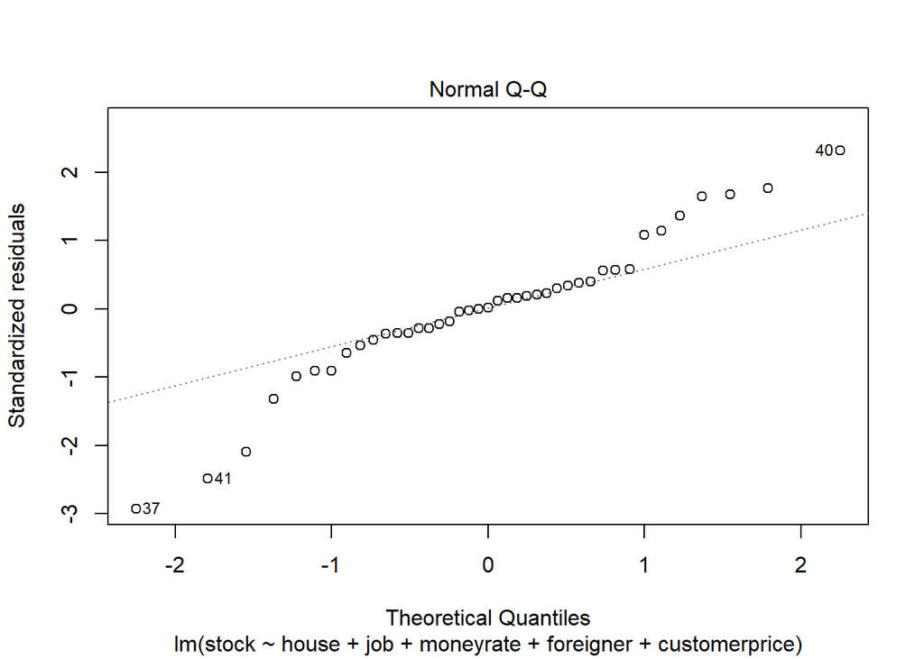

```r
plot(result3,2)
```

### 등분산성 확인

잔차들이 커지는 경향을 보이고 있어 추가적인 분석이 필요하다고 판단된다.

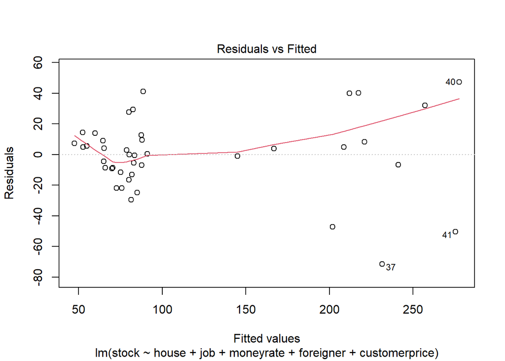

```r
plot(result3,1)
```

### log변환

분산을 안정화 시키기 위해서 종속변수인 stock에 log처리를 하고, 전체 변수 모델을 대상으로 stepAIC진행. 그 결과 coin변수가 제외됨.

```r
log_lm <- lm(log(stock)~house+moneyrate+coin + job +foreigner+customerprice,data=data2)
result4 <- stepAIC(log_lm)
```

```
## Start:  AIC=-122.59
## log(stock) ~ house + moneyrate + coin + job + foreigner + customerprice
##
##                 Df Sum of Sq    RSS     AIC
## - coin           1   0.04013 1.5056 -123.48
## <none>                       1.4654 -122.59
## - house          1   0.14792 1.6134 -120.65
## - job            1   0.17718 1.6426 -119.91
## - foreigner      1   0.19998 1.6654 -119.34
## - customerprice  1   0.26777 1.7332 -117.71
## - moneyrate      1   1.01907 2.4845 -102.94
##
## Step:  AIC=-123.48
## log(stock) ~ house + moneyrate + job + foreigner + customerprice
##
##                 Df Sum of Sq    RSS     AIC
## <none>                       1.5056 -123.48
## - foreigner      1   0.17305 1.6786 -121.02
## - job            1   0.17665 1.6822 -120.93
## - house          1   0.26825 1.7738 -118.76
## - customerprice  1   0.37276 1.8783 -116.41
## - moneyrate      1   0.99434 2.4999 -104.69
```

### 회귀분석

추정된 회귀식

#### $\hat{log(stock)} = 21.12 +0.03 house -0.7 moneyrate + 0.12job - 0.09foreigner -0.15 customerprice$

수정된 $R^2$값은 0.8634, $p-value$또한 낮다.

```r
summary(result4)
```

```
##
## Call:
## lm(formula = log(stock) ~ house + moneyrate + job + foreigner +
##     customerprice, data = data2)
##
## Residuals:
##      Min       1Q   Median       3Q      Max
## -0.45891 -0.07917  0.00111  0.10484  0.44330
##
## Coefficients:
##               Estimate Std. Error t value Pr(>|t|)
## (Intercept)   21.11940    5.29253   3.990 0.000321 ***
## house          0.02655    0.01063   2.497 0.017372 *
## moneyrate     -0.69702    0.14498  -4.808 2.86e-05 ***
## job            0.12357    0.06098   2.026 0.050387 .
## foreigner     -0.08608    0.04292  -2.006 0.052668 .
## customerprice -0.15395    0.05230  -2.944 0.005725 **
## ---
## Signif. codes:  0 '***' 0.001 '**' 0.01 '*' 0.05 '.' 0.1 ' ' 1
##
## Residual standard error: 0.2074 on 35 degrees of freedom
## Multiple R-squared:  0.8805, Adjusted R-squared:  0.8634
## F-statistic: 51.58 on 5 and 35 DF,  p-value: 3.64e-15
```

### 독립성 확인

$H_0$ : 잔차들이 서로 독립적이다.  
$H_1$ : 잔차들이 서로 독립적이지 않다.  
D-W statistic이 1.65로 2에 가깝고, $p-value$가 0.05이상이므로 잔차들은 서로 독립적이다

```r
durbinWatsonTest(result4)
```

```
##  lag Autocorrelation D-W Statistic p-value
##    1      0.09880391      1.646206   0.056
##  Alternative hypothesis: rho != 0
```

### 정규성 확인

$H_0$ : 잔차들이 정규성을 띄고있다.  
$H_1$ : 잔차들이 정규성을 띄고 있지않다.  
$p-valule$의 값이 0.8989로 0.05보다 크므로 잔차들은 정규성을 띄고 있다.  
하지만 1,32,4번 관측값을 제거하면 더 나은 모델을 만들 수 있을것으로 생각된다.

```r
shapiro.test(resid(result4))
```

```
##
##  Shapiro-Wilk normality test
##
## data:  resid(result4)
## W = 0.98645, p-value = 0.8989
```

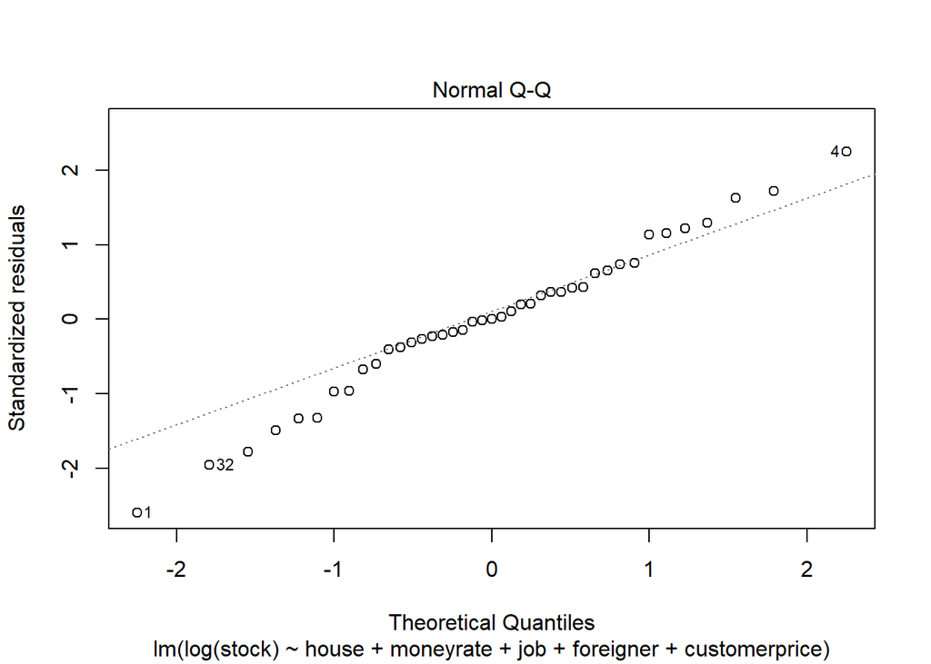

```r
plot(result4,2)
```

### 등분산성

등분산성이 log를 취하지 않은 다른 모델과 비교했을 때, 비교적 안정되었으나 여전히 경향성을 보이고 있으며,  
1,32,4번 관측치가 여전히 의심스럽다.

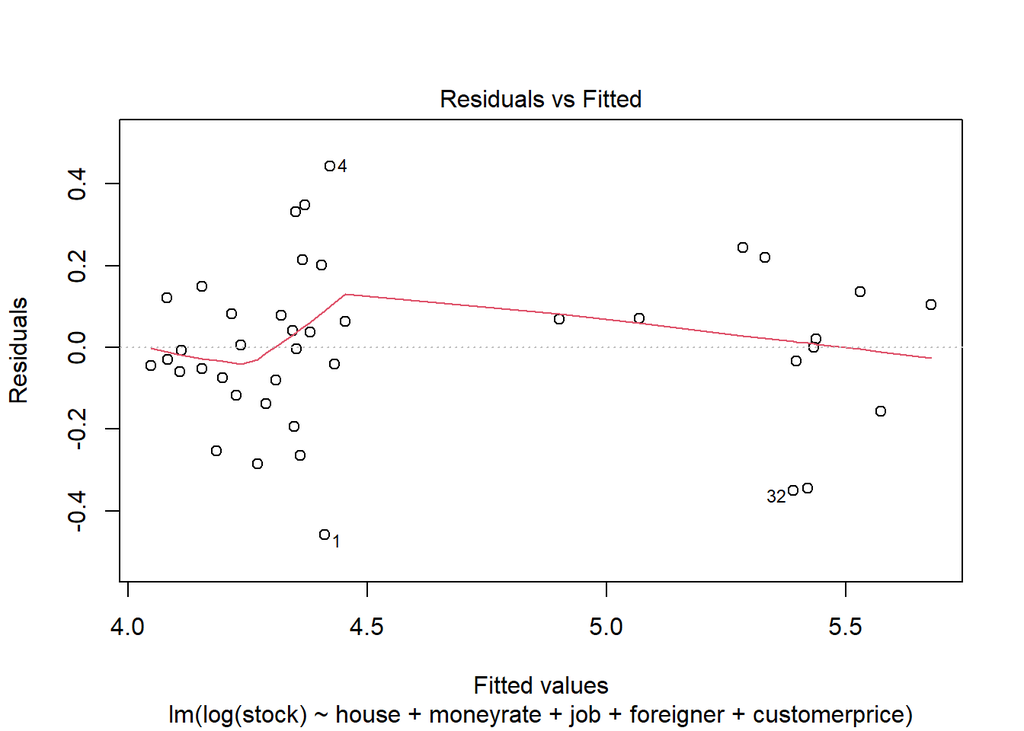

```r
plot(result4,1)
```

### 쿡의 거리

정말 제거해야하는 관측치들인지 판단하기 위해서 쿡의 거리를 비교해본다.  
그 결과 1번이 영향력을 제일 크게 발휘하므로 제거하기로 결정하였다.

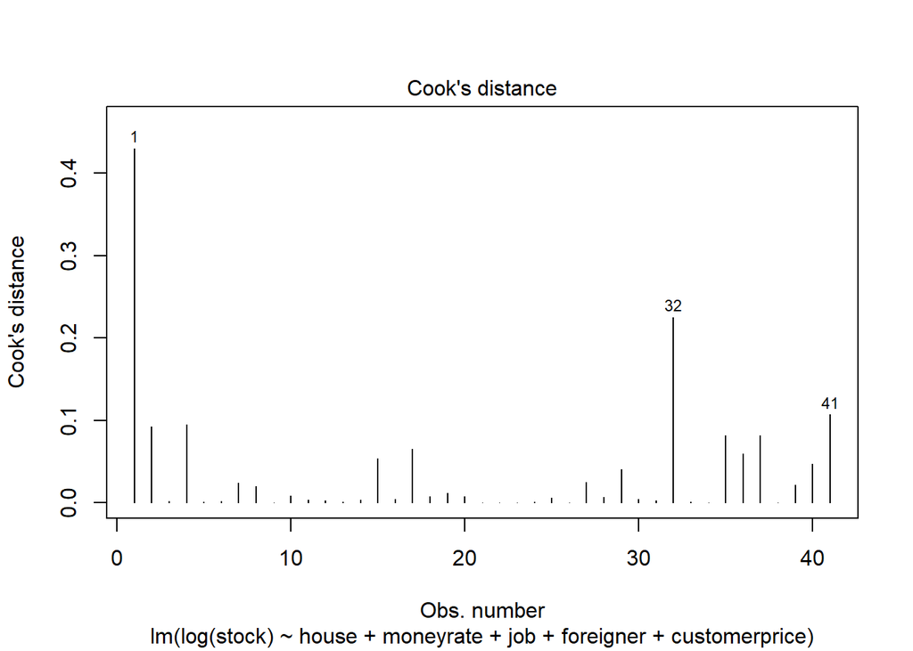

```r
plot(result4,4)
```

### 이상치 제거

1번 관측치를 제거하고, data5변수를 새롭게 생성 후 stepAIC를 이용하여 회귀 모델의 변수 선택을 진행하였다.  
그 결과 job, house, customerprice, moneyrate 4가지 변수를 이용한 모델이 최적 모델로 선택이 되었다.

```r
data5 <- data2[-1,]
log_lm <- lm(log(stock)~house+moneyrate+coin+job+foreigner+customerprice,data=data5)
result5 <- stepAIC(log_lm)
```

```
## Start:  AIC=-127.17
## log(stock) ~ house + moneyrate + coin + job + foreigner + customerprice
##
##                 Df Sum of Sq    RSS     AIC
## - foreigner      1   0.03735 1.2104 -127.92
## - coin           1   0.04161 1.2146 -127.78
## <none>                       1.1730 -127.17
## - job            1   0.14649 1.3195 -124.46
## - house          1   0.17079 1.3438 -123.73
## - customerprice  1   0.39975 1.5728 -117.44
## - moneyrate      1   1.22821 2.4013 -100.52
##
## Step:  AIC=-127.92
## log(stock) ~ house + moneyrate + coin + job + customerprice
##
##                 Df Sum of Sq    RSS      AIC
## - coin           1   0.02976 1.2401 -128.946
## <none>                       1.2104 -127.918
## - job            1   0.16221 1.3726 -124.887
## - house          1   0.20869 1.4191 -123.555
## - customerprice  1   0.43306 1.6434 -117.683
## - moneyrate      1   1.59704 2.8074  -96.264
##
## Step:  AIC=-128.95
## log(stock) ~ house + moneyrate + job + customerprice
##
##                 Df Sum of Sq    RSS      AIC
## <none>                       1.2401 -128.946
## - job            1   0.15955 1.3997 -126.105
## - house          1   0.33045 1.5706 -121.497
## - customerprice  1   0.54619 1.7863 -116.348
## - moneyrate      1   1.56767 2.8078  -98.259
```

### 회귀분석

추정된 회귀식

#### $\hat{log(stock)} = 22.27 + 0.03house -0.83moneyrate + 0.12job -0.19customerprice$

수정된 $R^2$의 값이 0.8865로 이전 모델보다 증가하였으며, $p-value$의 값도 매우 작아 신뢰할 수 있는 모델로 판단된다.  
동시에 각 회귀계수들의 p값도 0.05보다 작아 유의미한 회귀계수로 판단할 수 있다.

```r
summary(result5)
```

```
##
## Call:
## lm(formula = log(stock) ~ house + moneyrate + job + customerprice,
##     data = data5)
##
## Residuals:
##      Min       1Q   Median       3Q      Max
## -0.34526 -0.08325 -0.00506  0.07052  0.36849
##
## Coefficients:
##                Estimate Std. Error t value Pr(>|t|)
## (Intercept)   22.271420   4.724361   4.714 3.79e-05 ***
## house          0.029296   0.009593   3.054 0.004299 **
## moneyrate     -0.832063   0.125092  -6.652 1.08e-07 ***
## job            0.117164   0.055215   2.122 0.040992 *
## customerprice -0.192305   0.048980  -3.926 0.000386 ***
## ---
## Signif. codes:  0 '***' 0.001 '**' 0.01 '*' 0.05 '.' 0.1 ' ' 1
##
## Residual standard error: 0.1882 on 35 degrees of freedom
## Multiple R-squared:  0.8981, Adjusted R-squared:  0.8865
## F-statistic: 77.15 on 4 and 35 DF,  p-value: < 2.2e-16
```

### 다중공선성

모델에 사용된 변수들의 vif값이 10 이하이므로 양호하다고 판단된다.

```r
car::vif(result5)
```

```
##         house     moneyrate           job customerprice
##      5.648998      3.996053      1.177713      1.981859
```

### 독립성

$H_0$ : 잔차들이 서로 독립적이다.  
$H_1$ : 잔차들이 서로 독립적이지 않다.  
D-W statistic이 1.71로 2에 가깝고, $p-value$가 0.05보다 크므로 잔차들은 서로 독립적이라고 할 수 있다.

```r
durbinWatsonTest(result5)
```

```
##  lag Autocorrelation D-W Statistic p-value
##    1        0.129751      1.714692   0.106
##  Alternative hypothesis: rho != 0
```

### 정규성 확인

$H_0$ : 잔차들이 정규성을 띄고있다.  
$H_1$ : 잔차들이 정규성을 띄고 있지않다.  
$p-valule$의 값이 0.1188로 0.05보다 크므로 잔차들은 정규성을 띄고 있다.

```r
shapiro.test(resid(result5))
```

```
##
##  Shapiro-Wilk normality test
##
## data:  resid(result5)
## W = 0.95566, p-value = 0.1188
```

Normal QQ의 경우에는 이전과 큰 변화는 없다.

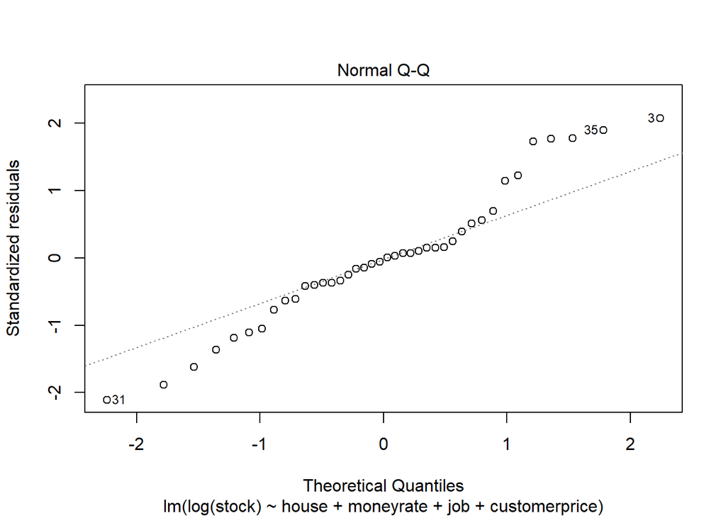

```r
plot(result5,2)
```

### 등분산성

등분산성이 log를 취하지 않거나 이상치를 제거하지 않은 다른 모델과 비교했을 때, 매우 안정된 것을 볼 수 있다.

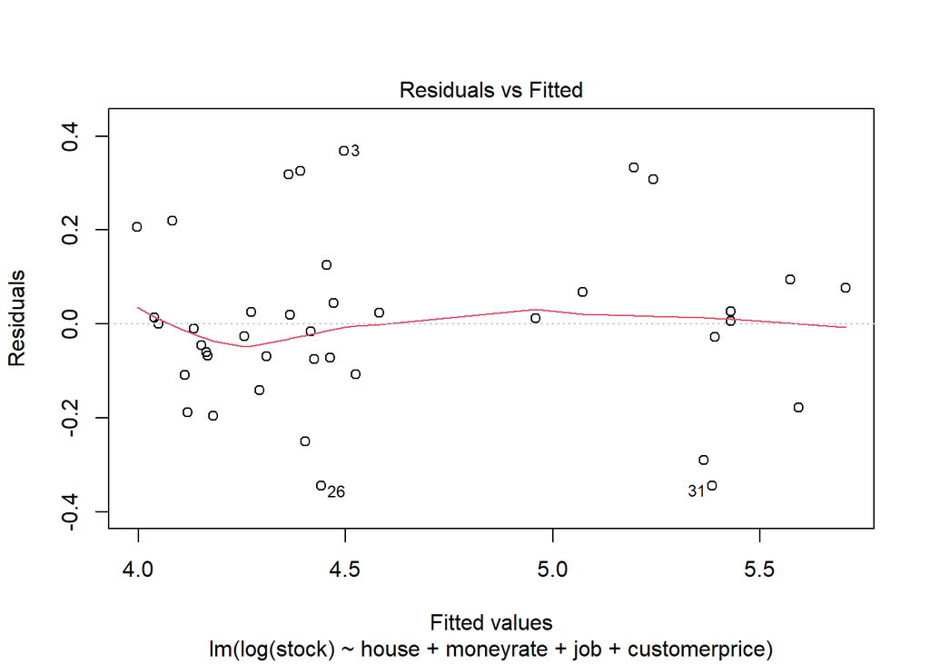

```r
plot(result5,1)
```

## 결론

### 표준화 회귀계수

독립변수들이 종속변수에 미치는 영향을 정확하게 파악하기 위해 표준화 회귀계수를 구했고, 그 결과는 다음과 같다.  
moneyrate,house,customerprice,job순서로 stock에 영향을 크게 미친다.

```r
lm.beta::lm.beta(result5)
```

```
##
## Call:
## lm(formula = log(stock) ~ house + moneyrate + job + customerprice,
##     data = data5)
##
## Standardized Coefficients::
##   (Intercept)         house     moneyrate           job customerprice
##     0.0000000     0.3915723    -0.7173274     0.1242327    -0.2981838
```

### 예측

예측을 위해 result5에 사용된 변수 4개의 2021.03 ~ 2021.05 기간을 가진 new_data라는 데이터 프레임 생성.  
해당 기간의 데이터가 공개되어 있으면 그 자료를 사용하고 그렇지 않은 경우 엑셀의 예측시트 생성 기능을 통해 추세에 따른 예측 값을 만들어서 사용하였다.

```r
house = c(127.3211,130.1539,132.9868)
moneyrate = c(0.5,0.5,0.5)
job = c(4.3,4.0,4.2)
customerprice = c(107.16,107.39,106.5348)

new_data = data.frame(house,moneyrate,job,customerprice)
head(new_data)
```

```
##      house moneyrate job customerprice
## 1 127.3211       0.5 4.3      107.1600
## 2 130.1539       0.5 4.0      107.3900
## 3 132.9868       0.5 4.2      106.5348
```

result5는 로그를 취한 상태이기에 원래의 결과값을 보기 위해서 exp를 적용한다.  
그 결과 2021년 3월의 예측 값은 240.28, 4월은 241.15, 5월은 316.17 이 나온것을 볼 수 있다.

```r
yearmonth = c("2021년 3월", "2021년 4월", "2021년 5월")
expect = exp(predict(result5,newdata = new_data,interval = "confidence"))

total = data.frame(yearmonth,expect)
total
```

```
##    yearmonth      fit      lwr      upr
## 1 2021년 3월 240.2778 190.0841 303.7256
## 2 2021년 4월 241.1467 181.1553 321.0048
## 3 2021년 5월 316.1729 226.6664 441.0238
```

2021년 03월의 주식시장 개인 거래실적이 분석 과정 중 공개되어 지수로 변환한 결과는 **221** 로,  
예측값의 95% 신뢰수준(190.0841,303.7256) 사이에 들어있으므로 이 모델을 가지고 진행한 예측이 유의하다고 말할 수 있다.